# HJB Equation and Merton’s Portfolio Problem

Final Oral Presentation

Guo Zhentao

2025-05-18

# Informal Problem Statement

- Assume: Current wealth is $W_0>0$, and you’ll live for $T$ more years
- You can invest $n$ risky assets and a risk less asset
- Each risky asset has known normal distribution of returns
- Allowed to long or short any fractional quantities of assets
- Trading in continuous time $0\leq t<T,$ with no transaction costs
- You can consume any fractional amount of wealth at any time
- Dynamic Decision: Optimal Allocation and Consumption at each time
- To maximize lifetime-aggregated utility of consumption
- Consumption Utility assumed to have Constant Relative Risk-Aversion

# Problem Notation

For simplicity, we state and solve the problem for $1$ risky asset but the solution generalizes easily to $n$ risky assets.

- Risk less Asset: $\frac{dR_t}{R_t}=rdt$
- Risky Asset: $\frac{dS_t}{S_t}=\mu dt+\sigma dW_t$ (i.e. Geometric Brownian)
- $\mu>r>0,\sigma>0$ (for $n$ assets, we work with a covariance matrix)
- Wealth at time $t$ is denoted by $X_t>0$
- Fraction of wealth allocated to risky asset denoted by $\pi(t,X_t)$, then the fraction of wealth in risk less asset will be $1-\pi(t,X_t)$
- Wealth consumption per unit time denoted by $c(t,X_t)\geq0$
- Utility of Consumption function

  $$\begin{align*}
  U(x)=
  \begin{cases}
  \frac{x^{1-\gamma}}{1-\gamma}\quad &0<\gamma<1,\\
  \log(x)\quad &\gamma=1.
  \end{cases}
  \end{align*}$$

  where $\gamma=$(Constant) Relative Risk-Aversion $\frac{-x\cdot U''(x)}{U'(x)}$

# Probelm Statement

- We write $\pi_t,c_t$ instead of $\pi(t,X_t),c(t,X_t)$ to lighten notation
- Balance constraint implies the following process for Wealth $X_t$

  $$dX_t=\left( (\pi_t\cdot(\mu-r)+r)\cdot X_t-c_t \right)\cdot
  dt+\pi_t\cdot\sigma\cdot X_t\cdot dW_t$$
- At any time $t,$ determine optimal $[\pi_t,c_t]$ to maximize:

  $$\mathbb{E}\left[\int_t^T\frac{e^{-\rho(s-t)}\cdot
  c_s^{1-\gamma}}{1-\gamma}\cdot ds+\frac{e^{-\rho(T-t)}\cdot B(T)\cdot
  X_T^{1-\gamma}}{1-\gamma} \mid X_t\right]$$
  where $\rho\geq0$ is the utility discount rate, $B(T)$ is the bequest function.
- We can solve this problem for arbitrary bequest $B(T)$ but for simplicity, will consider $B(T)=\epsilon^\gamma$ where $0<\epsilon\ll1,$ meaning “no bequest” (we need this $\epsilon$-formulation for technical reasons).
- We will solve this problem for $\gamma\neq1$($\gamma=1$ is easier, hence omitted)

# Continuous-Time Stochastic Control

- The *State* at time $t$ is $(t,X_t)$
- The *Action* at time $t$ is $[\pi_t,c_t]$
- The *Reward* per unit time at $t$ is $U(c_t)=\frac{c_t^{1-\gamma}}{1-\gamma}$
- The *Return* at time $t$ is the accumulated discounted *Reward*:

  $$\int_t^Te^{-\rho(s-t)}\cdot\frac{c_s^{1-\gamma}}{1-\gamma}\cdot ds$$
- Find *Policy*: $(t,X_t)\rightarrow [\pi_t,c_t]$ that maximizes the *Expected Return*
- Note: $c_t\geq0,$ but $\pi_t$ is unconstrained

# Optimal Value Function

- Value Function for a *State* (under a given policy) is the *Expected Return* from the *State* (when following the given policy)
- We focus on the Optimal Value Function $V^*(t,X_t)$

  $$V^*(t,X_t)=\max_{\pi,c_t}\mathbb{E}_t\left[
  \int_t^T\frac{e^{-\rho(s-t)}\cdot c_s^{1-\gamma}}{1-\gamma}\cdot
  ds+\frac{e^{-\rho(T-t)}\cdot\epsilon^\gamma\cdot
  X_T^{1-\gamma}}{1-\gamma} \right]$$
- $V^*(t,X_t)$ satisfies a simple recursive formulation for $0\leq t<t_1<T$

  $$V^*(t,X_t)=\max_{\pi,c_t}\mathbb{E}_t\left[
  \int_t^{t_1}\frac{e^{-\rho(s-t)}\cdot c_s^{1-\gamma}}{1-\gamma}\cdot
  ds+e^{-\rho(t_1-t)}\cdot V^*(t_1,X_{t_1}) \right]$$

  $$\Rightarrow e^{-\rho t}\cdot V^*(t,X_t)=\max_{\pi,c_t}\mathbb{E}_t\left[
  \int_t^{t_1}\frac{e^{-\rho s}\cdot c_s^{1-\gamma}}{1-\gamma}\cdot
  ds+e^{-\rho t_1}\cdot V^*(t_1,X_{t_1}) \right]$$

# HJB Equation for Optimal Value Function

Rewriting in stochastic differential form, we have the HJB formulation

$$\begin{align*}
&\max_{\pi_t,c_t}\mathbb{E}_t\left[ d(e^{-\rho t}\cdot
V^*(t,X_t))+\frac{e^{-rho t}\cdot c_t^{1-\gamma}}{1-\gamma}\cdot dt
\right]=0\\
\Rightarrow &\max_{\pi_t,c_t}\mathbb{E}_t\left[
dV^*(t,X_t)+\frac{c_t^{1-\gamma}}{1-\gamma}\cdot dt \right]=\rho\cdot
V^*(t,X_t)\cdot dt
\end{align*}$$

Use Ito’s Lemma on $dV^*$, remove the $dW_t$ term since it’s a martingale, and divide throught by $dt$ to produce the HJB Equation in PDE form:

$$\max_{\pi_t,c_t}\left[\frac{\partial V^*}{\partial t}+\frac{\partial
V^*}{\partial
x}\left((\pi_t(\mu-r)+r)X_t-c_t\right)+\frac{\partial^2V^*}{\partial
x^2}\cdot\frac{\pi_t^2\sigma^2X_t^2}{2}+\frac{c_t^{1-\gamma}}{1-\gamma}
\right]=\rho\cdot V^*(t,X_t)$$

Let us writhe the above equation more succinctly as:

$$\max_{\pi_t,c_t}J(t,X_t;\pi_t,c_t)=\rho\cdot V^*(t,X_t)$$

# Optimal Allocation and Consumption

Find optimal $\pi^*_t,c_t^*$ by taking partial derivatives of $J(t,X_t;\pi_t,c_t)$ with respect to $\pi_t$ and $c_t$, and equate to $0$ (first-order conditions for $J$).

$$\pi^*_t=\frac{-\frac{\partial V^*}{\partial x}\cdot
(\mu-r)}{\frac{\partial^2V^*}{\partial x^2}\cdot\sigma^2\cdot X_t},\quad
c_t^*=\left(\frac{\partial V^*}{\partial x}\right)^{-\frac{1}{\gamma}}$$

# Optimal Value Function PDE

Now substitute $\pi_t^*$ and $c_t^*$ in $J(t,X_t;\pi_t,c_t)$ and equate to $\rho V^*(t,X_t)$, which gets us the Optimal Value Function PDE:

$$\frac{\partial V^*}{\partial
t}-\frac{(\mu-r)^2}{2\sigma^2}\cdot\frac{\left(\frac{\partial
V^*}{\partial x}\right)^2}{\frac{\partial^2 V^*}{\partial
x^2}}+\frac{\partial V^*}{\partial x}\cdot r\cdot
X_t+\frac{\gamma}{1-\gamma}\cdot\left(\frac{\partial V^*}{\partial
x}\right)^{\frac{\gamma-1}{\gamma}}=\rho V^*$$

The boundary condition is

$$V^*(T,X_T)=\epsilon^\gamma\cdot\frac{W_T^{1-\gamma}}{1-\gamma}$$
The second-order conditions for $J$ are satisfied **under the assumptions** $c_t^*>0,X_t>0,\frac{\partial^2 V^*}{\partial x^2}<0$ for all $0\leq t<T$, and for concave $U(\cdot),$ i.e., $\gamma>0$

# Soloving the PDE with a guess solution

We surmise with a guess solution

$$V^*(t,X_t)=f(t)^{\gamma}\cdot\frac{X_t^{1-\gamma}}{1-\gamma}$$

Then, we substituting the guess solution in the PDE, we get the simple ODE, and with boundary condition $f(T)=\epsilon$, we can obtain the solution to this ODE is

$$f(t)=
\begin{cases}
\frac{1+(\nu\epsilon-1)e^{-\nu(T-t)}}{\nu},&\nu\neq0\\
T-t+\epsilon,&\nu=0
\end{cases}$$
where $\nu=\frac{\rho-(1-\gamma)\cdot\left( \frac{(\mu-r)^2}{2\sigma^2\gamma}+r \right)}{\gamma}$.

# Optimal Allocation and Consumption

Putting ti all together, we get

$$\begin{align*}
&\pi^*(t,X_t)=\frac{\mu-r}{\sigma^2\gamma}\\
&c^*(t,X_t)=\begin{cases}
\frac{\nu X_t}{1+(\nu\epsilon-1)e^{-\nu(T-t)}},&\nu\neq0\\
\frac{X_t}{T-t+\epsilon},&\nu=0
\end{cases}\\
&V^*(t,X_t)=\begin{cases}
\frac{\left(1+(\nu\epsilon-1)e^{-\nu(T-t)}\right)^{\gamma}}{\nu^{\gamma}}\cdot
\frac{X_t^{1-\gamma}}{1-\gamma},&\nu\neq0\\
\frac{\left(T-t+\epsilon\right)^\gamma\cdot
X_t^{1-\gamma}}{1-\gamma},&\nu=0
\end{cases}
\end{align*}$$

# Gaining Insights into the Solution

- Optimal Allocation $\pi^*(t,X_t)$ is constant (independent of $t$ and $X_t$)
- Optimal Fractional Consumption $\frac{c^*(t,X_t)}{X_t}$ depends only on $t$($=\frac{1}{f(t)}$).
- With Optimal Allocation & Consumption, the Wealth process is:

  $$\frac{dW_t}{W_t}=\left(
  r+\frac{(\mu-r)^2}{\sigma^2\gamma}-\frac{1}{f(t)}\right)\cdot
  dt+\frac{\mu-r}{\sigma\gamma}\cdot dW_t$$
- Expected Portfolio Returns is constant over time
- Assuming $\epsilon<\frac{1}{\nu}$, Fractional Consumption $\frac{1}{f(t)}$ increases over time
- If $r+\frac{(\mu-r)^2}{\sigma^2\gamma}>\frac{1}{f(0)},$ we start by Consuming $<$ Expected Portfolio Growth and pver time, we Consume $>$ Expected Portfolio Growth
- Wealth Growth Volatility is constant ($=\frac{\mu-r}{\sigma\gamma}$)

# Portfolio Return versus Consumption Rate

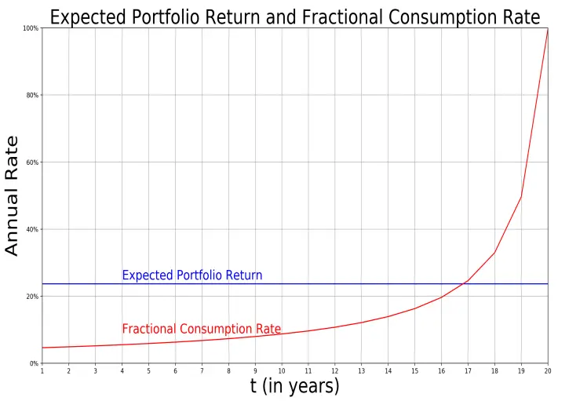

Thanks!